# Importing and Processing CSV Files

Marc Los Huertos

12/6/2016

## Importing CSV Files

First, we will import the CSV file. In most cases, we don’t need to preprocess the csv files.

```r
#Importing Scripts

file = "/home/CAMPUS/mwl04747/github/Climate_Change_Narratives/Nicole/Marshfield climate.csv"
import = read.csv(file)
```

## Checking the Data

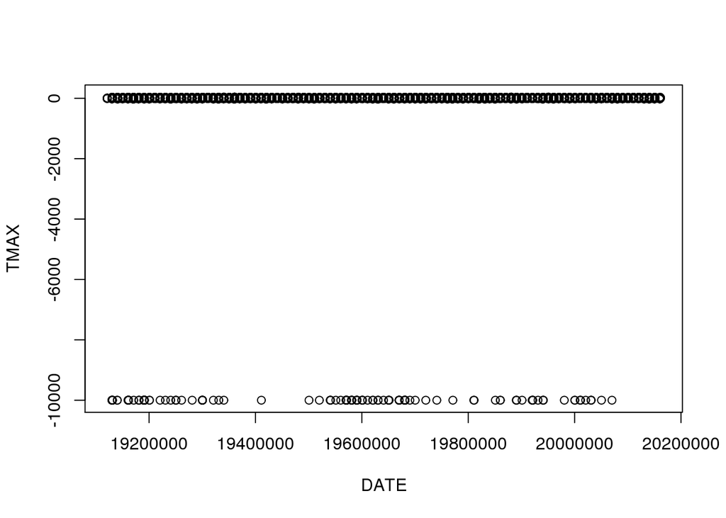

```r
plot(TMAX~DATE, import)
```

What’s going on? What is the deal with the -9999? These are used for missing data. We need to remove them!

```r
import$TMAX[import$TMAX==-9999] = NA
```

Okay, now we’ll check again, for dates less then Dec. 31, 1913:

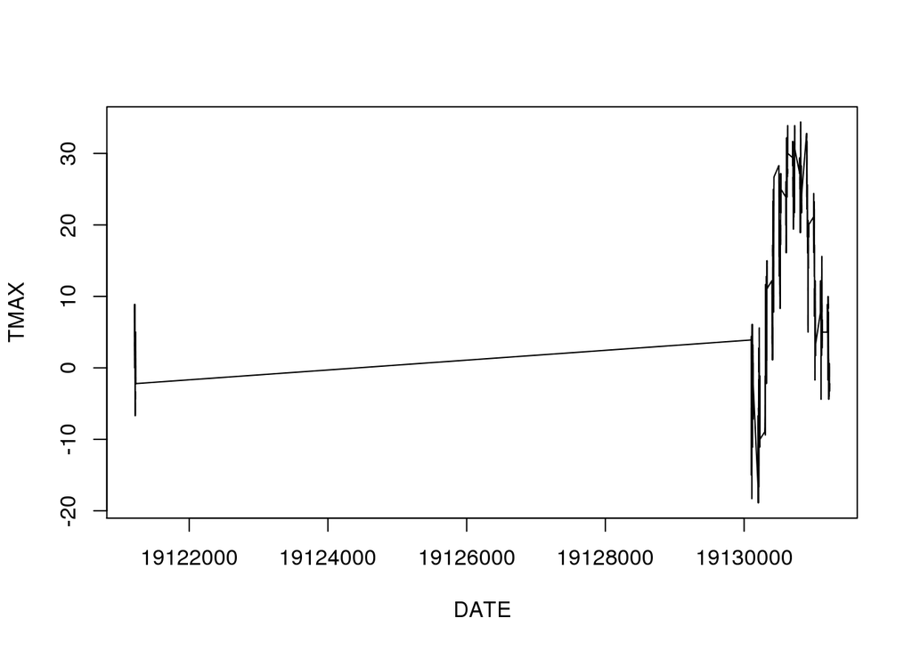

```r
plot(TMAX~DATE, import[import$DATE<19132131,], ty='l')
```

Yikes! What’s wrong? As it turns it the problem is that with how the dates are specified. In particular, the Dec 31 to Jan 1 transition:

191231 -> 190102, if you use these as numbers it should be 121232, 12121233, etc. You see we are missing lots numbers!

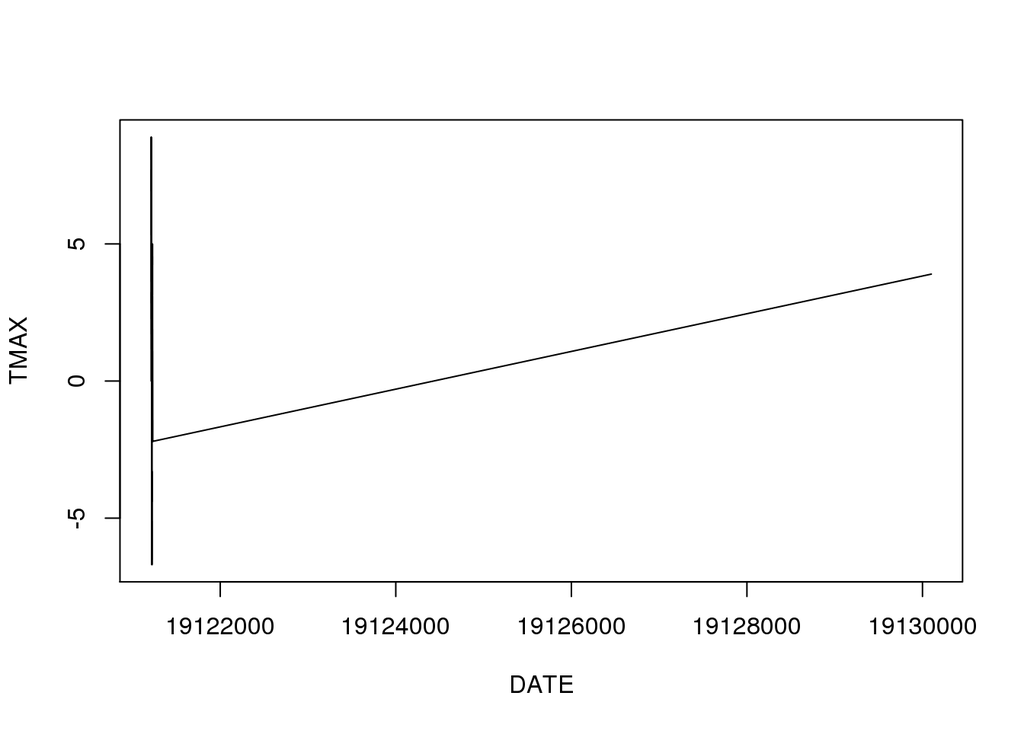

```r
plot(TMAX~DATE, import[import$DATE<19130102,], ty='l')
```

## Fixing the Dates

First, we convert the date a string or character values. Next, we’ll convert the strings to a data format.

```r
strDates <- as.character(import$DATE)
head(strDates)
```

```
## [1] "19121213" "19121214" "19121215" "19121216" "19121217" "19121218"
```

```r
import$NewDate <- as.Date(strDates, "%Y%m%d")
```

## Checking the New Dates

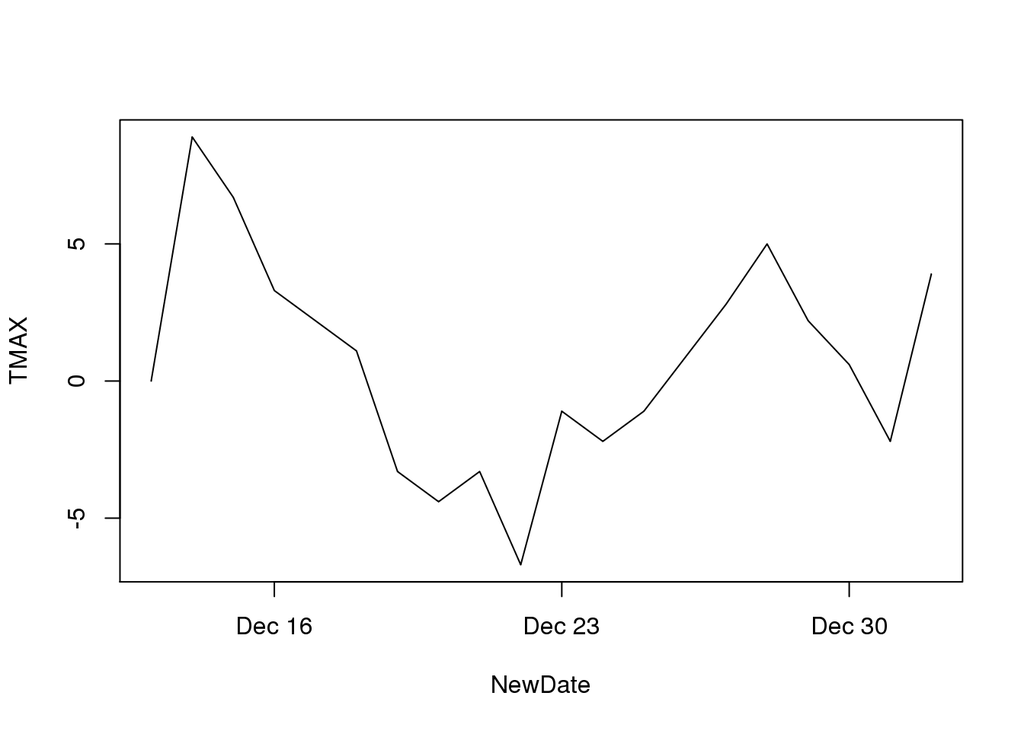

```r
plot(TMAX~NewDate, import[import$DATE<19130102,], ty='l')
```

## A new plot

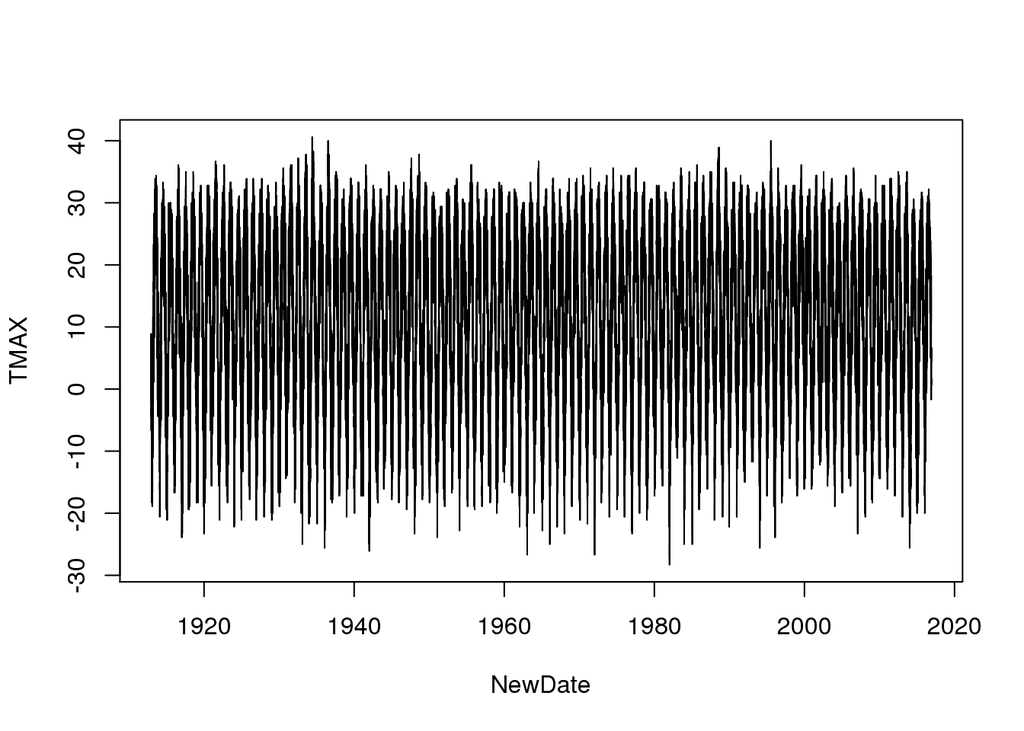

```r
plot(TMAX~NewDate, import, ty='l')
```

## Evaluating the trend

Creating a linear model and then evaluate the rate (slope).

```r
# Linear Model
import.lm <- lm(TMAX~NewDate, data=import)
summary(import.lm)
```

```
##
## Call:
## lm(formula = TMAX ~ NewDate, data = import)
##
## Residuals:
##     Min      1Q  Median      3Q     Max
## -40.587 -10.816   1.451  11.401  28.819
##
## Coefficients:
##              Estimate Std. Error t value Pr(>|t|)
## (Intercept) 1.216e+01  6.698e-02 181.527  < 2e-16 ***
## NewDate     2.906e-05  6.033e-06   4.817 1.46e-06 ***
## ---
## Signif. codes:  0 '***' 0.001 '**' 0.01 '*' 0.05 '.' 0.1 ' ' 1
##
## Residual standard error: 12.84 on 37743 degrees of freedom
##   (177 observations deleted due to missingness)
## Multiple R-squared:  0.0006144,  Adjusted R-squared:  0.0005879
## F-statistic:  23.2 on 1 and 37743 DF,  p-value: 1.464e-06
```

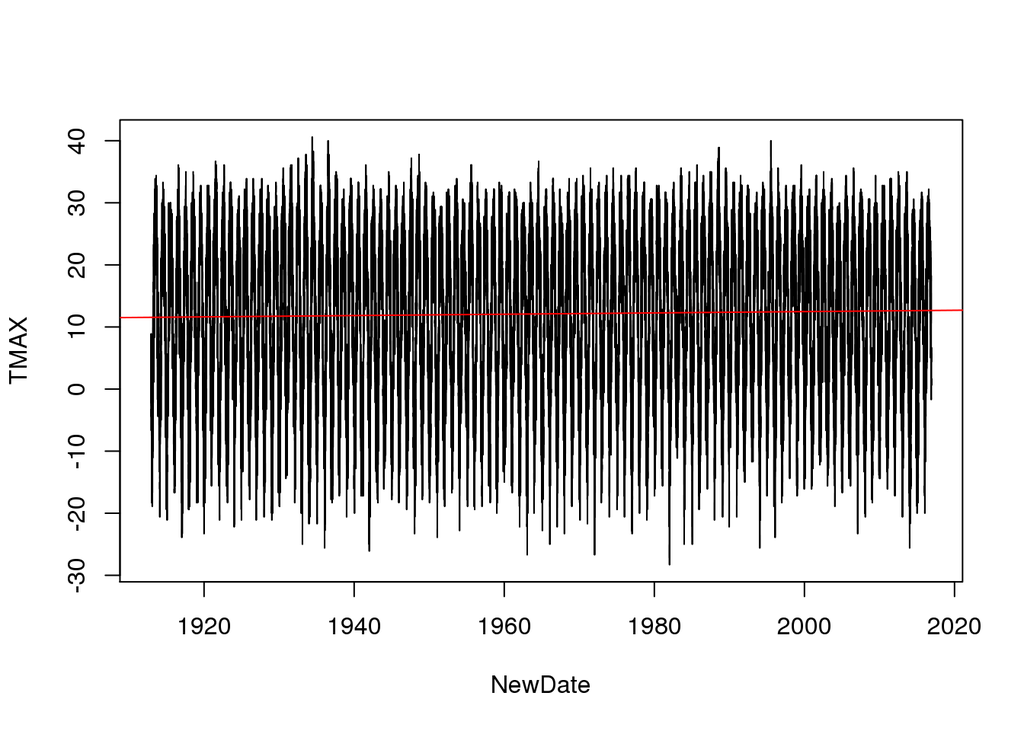

```r
plot(TMAX~NewDate, import, ty='l')
abline(coef(import.lm), col='red')
```

## Time Series

Time series data require specific statistical methods. I started thiking about how to do this in R, but didn’t finish… so this is superfolous for now.

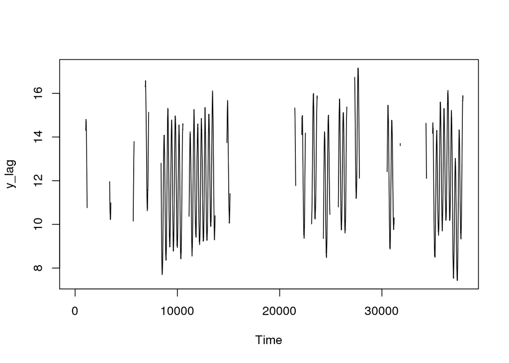

```r
#2.906*10-5 degrees/year or 2.9*10-2 per year.

# Moving Average!
# average of current sample and 19 previous samples (red)
f20 <- rep(1/600, 600)
y_lag <- filter(import$TMAX, f20, sides=1)
plot(y_lag)
```

```r
# Create a time series
Tmax = ts(import$TMAX)
```

## Creating Months and Year

So, let’s figure out how to see how changes happen for individual months.

```r
# Get months
import$Month = months(import$NewDate)
import$Year = format(import$NewDate, format="%Y")

MonthlyMean = aggregate(TMAX ~ Month + Year, import, mean)
MonthlyMean$YEAR = as.numeric(MonthlyMean$Year)
head(MonthlyMean)
```

```
##      Month Year       TMAX YEAR
## 1 December 1912  0.4722222 1912
## 2    April 1913 13.8166667 1913
## 3   August 1913 25.8580645 1913
## 4 December 1913  2.7000000 1913
## 5 February 1913 -5.6607143 1913
## 6  January 1913 -3.8129032 1913
```

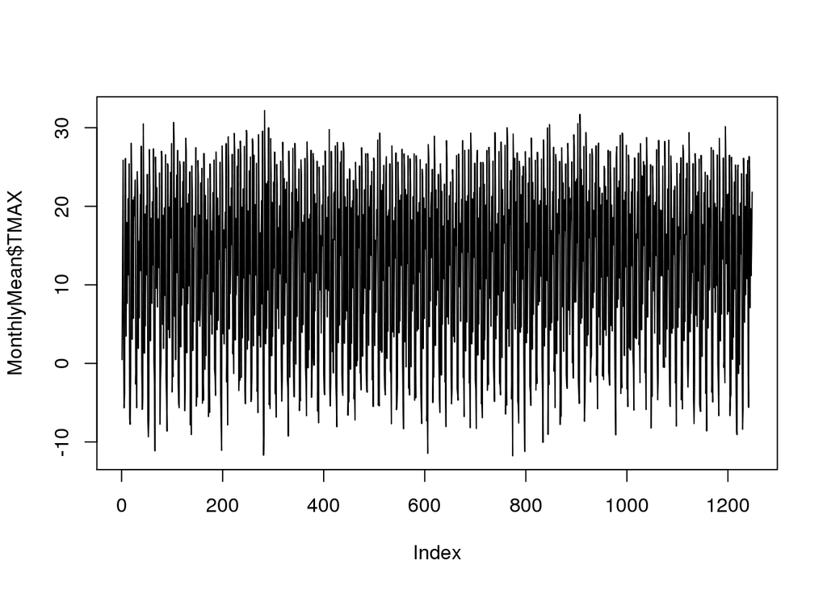

```r
plot(MonthlyMean$TMAX, ty='l')
```

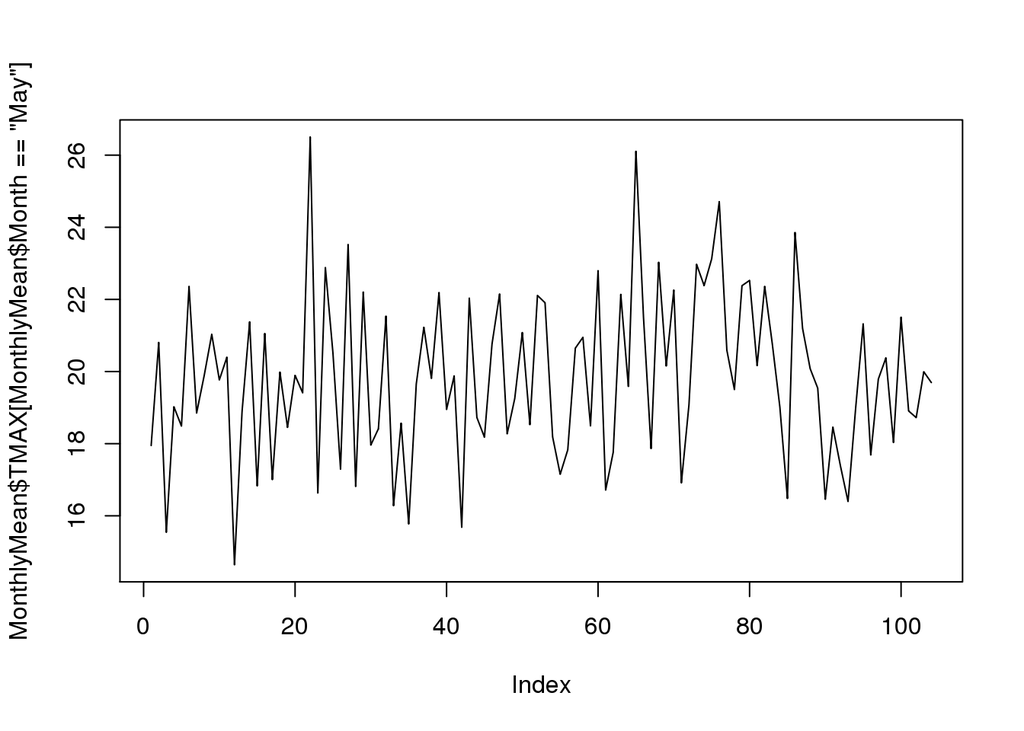

```r
plot(MonthlyMean$TMAX[MonthlyMean$Month=="May"], ty='l')
```

```r
plot(TMAX~YEAR, data=MonthlyMean[MonthlyMean$Month=="May",], ty='l')
May.lm <- lm(TMAX~YEAR, data=MonthlyMean[MonthlyMean$Month=="May",])
summary(May.lm)
```

```
##
## Call:
## lm(formula = TMAX ~ YEAR, data = MonthlyMean[MonthlyMean$Month ==
##     "May", ])
##
## Residuals:
##     Min      1Q  Median      3Q     Max
## -4.8617 -1.5296 -0.1008  1.5565  6.9213
##
## Coefficients:
##              Estimate Std. Error t value Pr(>|t|)
## (Intercept)  4.404709  14.782927   0.298    0.766
## YEAR         0.007848   0.007524   1.043    0.299
##
## Residual standard error: 2.304 on 102 degrees of freedom
## Multiple R-squared:  0.01055,    Adjusted R-squared:  0.0008521
## F-statistic: 1.088 on 1 and 102 DF,  p-value: 0.2994
```

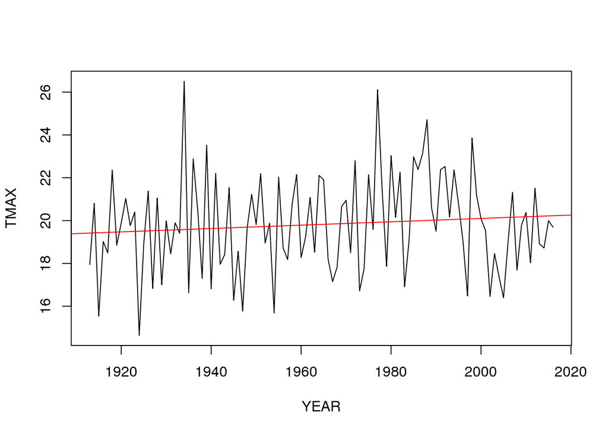

```r
abline(coef(May.lm), col="red")
```

Now, the change is 0.0078 (0.008/year), or 0.8/100 years.

## Next Steps

I think you should evaluate every month and see what happens. You might also consider looking at the TMIN as well. Could be important!